# AllGreensFranchise

Siva Bulusu

October 5, 2019

## All Greens Franchise

Explain the importance of X2, X3, X4, X5, X6 on Annual Net Sales, X1. The data (X1, X2, X3, X4, X5, X6) are for each franchise store. X1 = annual net sales/$1000 X2 = number sq. ft./1000 X3 = inventory/$1000 X4 = amount spent on advertising/$1000 X5 = size of sales district/1000 families X6 = number of competing stores in district

## Solution

X1 is the dependent variable. All others (X2, X2, X3, X4, X5, X6) are independent variables.

Include required libraries.

```r
library(readxl)
```

```r
library(corrplot)
library(car)
```

Import data and have a look.

```r
AllGreensData <- read_excel("Dataset_All Greens Franchise.xls", sheet = "Mlr05")
View(AllGreensData)
```

```r
str(AllGreensData)
```

```
## Classes 'tbl_df', 'tbl' and 'data.frame':    27 obs. of  6 variables:
##  $ X1: num  231 156 10 519 437 487 299 195 20 68 ...
##  $ X2: num  3 2.2 0.5 5.5 4.4 ...
##  $ X3: num  294 232 149 600 567 571 512 347 212 102 ...
##  $ X4: num  8.2 6.9 3 12 10.6 ...
##  $ X5: num  8.2 4.1 4.3 16.1 14.1 ...
##  $ X6: num  11 12 15 1 5 4 10 12 15 8 ...
```

Check for missing values in the dataset.

```r
sapply(AllGreensData,function(x){sum(is.na(x))})
```

```
## X1 X2 X3 X4 X5 X6
##  0  0  0  0  0  0
```

Check for correlation among the variables in the dataset.

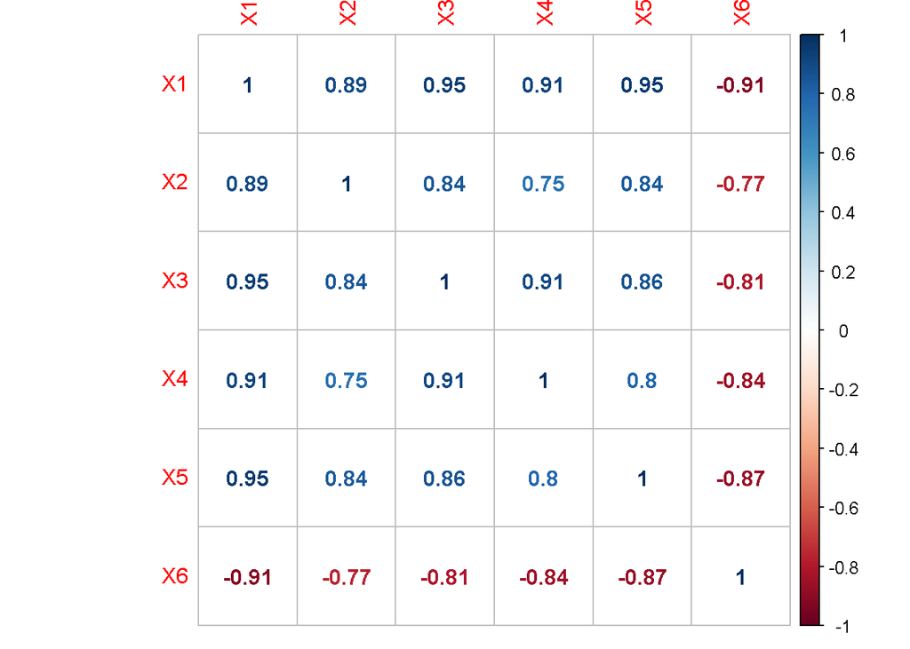

```r
corel<-cor(AllGreensData)
corrplot(corel,method ="number")
```

All independent variables have high correlation with dependent variable. However, the dependent variables are also correlated among with each other which indicates multicollinearity. This is not good.

Build a model using the dataset and check the summary.

```r
#Build first model considering all data
reg1 <- lm(X1 ~ ., data= AllGreensData)
summary(reg1)
```

```
##
## Call:
## lm(formula = X1 ~ ., data = AllGreensData)
##
## Residuals:
##     Min      1Q  Median      3Q     Max
## -26.338  -9.699  -4.496   4.040  41.139
##
## Coefficients:
##              Estimate Std. Error t value Pr(>|t|)
## (Intercept) -18.85941   30.15023  -0.626 0.538372
## X2           16.20157    3.54444   4.571 0.000166 ***
## X3            0.17464    0.05761   3.032 0.006347 **
## X4           11.52627    2.53210   4.552 0.000174 ***
## X5           13.58031    1.77046   7.671 1.61e-07 ***
## X6           -5.31097    1.70543  -3.114 0.005249 **
## ---
## Signif. codes:  0 '***' 0.001 '**' 0.01 '*' 0.05 '.' 0.1 ' ' 1
##
## Residual standard error: 17.65 on 21 degrees of freedom
## Multiple R-squared:  0.9932, Adjusted R-squared:  0.9916
## F-statistic: 611.6 on 5 and 21 DF,  p-value: < 2.2e-16
```

R-squared and Adjusted R-squared are pretty good. So X1 is very well explained by other independent variables.

Check VIF on the model to handle multi collinearity.

```r
vif(reg1)
```

```
##        X2        X3        X4        X5        X6
##  4.240914 10.122480  7.624391  6.912318  5.818768
```

X3 has very high VIF which is greater than 10 among the independent variables. This should not be considered for our model.

Build another model by dropping X3 as it has very high VIF.

```r
#VIF of X3 is greater than 10.Drop this variable from the model and build one more.
reg2 <- lm(X1 ~ .-X3, data= AllGreensData)
summary(reg2)
```

```
##
## Call:
## lm(formula = X1 ~ . - X3, data = AllGreensData)
##
## Residuals:
##     Min      1Q  Median      3Q     Max
## -30.422 -12.858  -6.477  16.160  45.255
##
## Coefficients:
##             Estimate Std. Error t value Pr(>|t|)
## (Intercept)  -39.460     34.411  -1.147   0.2638
## X2            20.444      3.815   5.359 2.22e-05 ***
## X4            16.966      2.093   8.107 4.73e-08 ***
## X5            15.673      1.910   8.206 3.86e-08 ***
## X6            -4.043      1.937  -2.088   0.0486 *
## ---
## Signif. codes:  0 '***' 0.001 '**' 0.01 '*' 0.05 '.' 0.1 ' ' 1
##
## Residual standard error: 20.68 on 22 degrees of freedom
## Multiple R-squared:  0.9902, Adjusted R-squared:  0.9884
## F-statistic: 555.4 on 4 and 22 DF,  p-value: < 2.2e-16
```

R-squared and Adjusted R-squared are good. And all variables X2, X4, X5, X6 are significant.

Check VIF again on the model to verify multi collinearity among X2, X4, X5, X6.

```r
vif(reg2)
```

```
##       X2       X4       X5       X6
## 3.579850 3.795323 5.861520 5.468943
```

VIF for X2, X4, X5, X6 is less than 10. This is good sign.

Apply PCA on the dataset and check summary.

```r
#Use PCA for handling multicollinearity
pca1 <- prcomp(AllGreensData[,-1], scale. = T)
summary(pca1)
```

```
## Importance of components:
##                           PC1    PC2     PC3     PC4     PC5
## Standard deviation     2.0769 0.5277 0.47972 0.35207 0.23260
## Proportion of Variance 0.8627 0.0557 0.04603 0.02479 0.01082
## Cumulative Proportion  0.8627 0.9184 0.96439 0.98918 1.00000
```

Get the X1 and PC1 in to new data frame.

```r
#Get X1 and PC1 in one data frame.
AGFdata<- data.frame(AllGreensData[,1], pca1$x[,1])
colnames(AGFdata) <- c("X1", "PC1")
AGFdata
```

```
##       X1         PC1
## 1  231.0 -0.71020022
## 2  156.0 -1.63725191
## 3   10.0 -2.91834663
## 4  519.0  2.61602854
## 5  437.0  1.59484864
## 6  487.0  1.79976793
## 7  299.0  0.08093258
## 8  195.0 -0.82313552
## 9   20.0 -2.77438351
## 10  68.0 -2.11512633
## 11 570.0  3.34759442
## 12 428.0  1.37357406
## 13 464.0  1.92620930
## 14  15.0 -2.99002186
## 15  65.0 -2.24620922
## 16  98.0 -2.17451195
## 17 398.0  0.68993008
## 18 161.0 -1.49865485
## 19 397.0  0.96895091
## 20 497.0  2.33467793
## 21 528.0  2.79092840
## 22  99.0 -2.28292792
## 23   0.5 -2.75946777
## 24 347.0  0.71215769
## 25 341.0  0.63290101
## 26 507.0  2.56105702
## 27 400.0  1.50067918
```

X1 and PC1 are in same data frame. We can build model on this.

Build a model on that uses X1 and PC1. X1 should be explained by PC1 by the created equation. Check the summary.

```r
#Build regression model using PC1.
reg3 <- lm(X1 ~ ., data=AGFdata)
summary(reg3)
```

```
##
## Call:
## lm(formula = X1 ~ ., data = AGFdata)
##
## Residuals:
##     Min      1Q  Median      3Q     Max
## -32.168 -15.059  -3.809  11.915  47.944
##
## Coefficients:
##             Estimate Std. Error t value Pr(>|t|)
## (Intercept)  286.574      3.774   75.94   <2e-16 ***
## PC1           92.013      1.852   49.69   <2e-16 ***
## ---
## Signif. codes:  0 '***' 0.001 '**' 0.01 '*' 0.05 '.' 0.1 ' ' 1
##
## Residual standard error: 19.61 on 25 degrees of freedom
## Multiple R-squared:   0.99,  Adjusted R-squared:  0.9896
## F-statistic:  2469 on 1 and 25 DF,  p-value: < 2.2e-16
```

R-squared and Adjusted R-squared are very good around 99%. And PC1 is highly significant.

From above summary annual sales can be predicted by the following equation.

X1 = 286.574 + 92.013 * PC1